# GLM para dados Discretos

Ana Karolina Silva

## 1 Introdução

Dados discretos são aqueles que só podem assumir valores inteiros (ou seja, não fracionários) e, geralmente, representam contagens.

Para exercitar o modelo de distribuição de Poisson, usei os dados das Salamandras extraídos do pacote glmmTMB - data(“Salamanders”). Cedido originalmente por Price et al. (2015, 2016)., que estão armazenados no diretório `/Dados` da disciplina.

```r
#~~~~~~~~~~~~~~~~~~~~~~~~~~~~~~~~
# 1. Importando o banco de dados
#~~~~~~~~~~~~~~~~~~~~~~~~~~~~~~~~

dados <- readRDS("../Dados/Salamanders.rds")
```

Visualizando informações contidas no banco de dados:

```r
#~~~~~~~~~~~~~~~~~~~~~~~~~~
# 2. Análise exploratória
#~~~~~~~~~~~~~~~~~~~~~~~~~~
str(dados)
```

```
## 'data.frame':    92 obs. of  14 variables:
##  $ site                      : Ord.factor w/ 23 levels "R-1"<"R-2"<"R-3"<..: 1 1 1 1 2 2 2 2 3 3 ...
##  $ mined                     : Factor w/ 2 levels "yes","no": 2 2 2 2 2 2 2 2 2 2 ...
##  $ cover                     : num  -0.448 -0.448 -0.448 -0.448 0.597 ...
##  $ sample                    : int  1 2 3 4 1 2 3 4 1 2 ...
##  $ DOP                       : num  0 -0.3018 0 -0.0916 0.5957 ...
##  $ Wtemp                     : num  -3.023 -1.365 -0.583 0.18 -0.144 ...
##  $ DOY                       : num  -2.712 -0.525 0.164 1.257 -0.687 ...
##  $ Gyrinophilus_porphyriticus: int  2 1 6 2 2 5 5 0 1 6 ...
##  $ Pseudotriton_ruber        : int  4 0 2 1 0 0 0 0 0 0 ...
##  $ Desmognathus_monticola    : int  3 2 3 2 4 6 3 3 1 4 ...
##  $ Eurycea_cirrigera_Adult   : int  2 0 0 0 0 0 2 0 2 0 ...
##  $ Eurycea_cirrigera_Larval  : int  1 6 4 13 2 2 3 11 0 0 ...
##  $ Desmognathus_spp_Larval   : int  1 8 7 2 4 2 14 0 10 8 ...
##  $ Desmognathus_fuscus       : int  1 0 0 0 1 1 1 2 0 0 ...
```

## 2 Análise exploratória (breve)

As variáveis do banco de dados estão caracterizadas de acordo com a sua natureza (*Factor*, *numeric*, *integer*, etc.) e escalonadas com z-score.

- Temos as seguintes informações:
- Local de amostragem
- Região que sofreu ou não mineração
- No. de objetos cobrindo a região (pedras, troncos de madeira, etc.; padronizado)
- No. da amostra (4 réplicas dentro de cada ‘site’)
- Dias transcorridos desde a última precipitação (padronizado)
- Temperatura da água (padronizada)
- Dia do ano (padronizado)

Vamos verificar possível colinearidades.

```r
#~~~~~~~~~~~~~~~~~~~~~~~~~~
# verificando colinearidade
#~~~~~~~~~~~~~~~~~~~~~~~~~~
library(GGally)
```

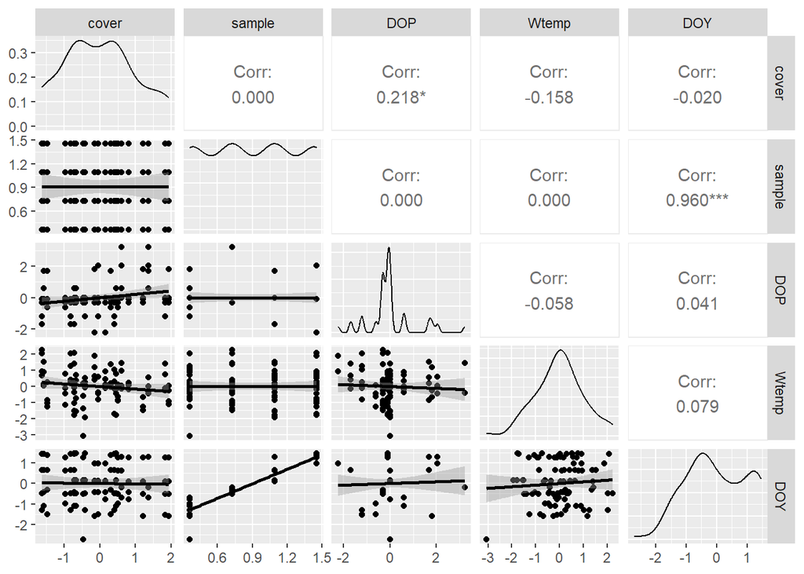

```r
dados[,3:7] <- scale(dados[,3:7], scale=T, center=F)

ggpairs(dados,
        columns = c(3:7),
        lower = list(continuous = "smooth")) # Columns
```

- Observa-se um correlação de 0,96 entre sample e DOY.

## 3 Analisando a distribuição do estágio larval da espécie Eurycea_cirrigera_Larval com variáveis ambientais e o tempo

A coluna `Wtemp` armazena informações sobre a temperatura da água; A coluna `DOY` armazena dia do ano; A coluna `DOP` armazena dias transcorridos desde a última precipitação; A coluna `mined` contém se a região sofreu ou não com mineração (fator).

Explorando a distribuição do estágio larval dessa espécie com relação a estas variáveis:

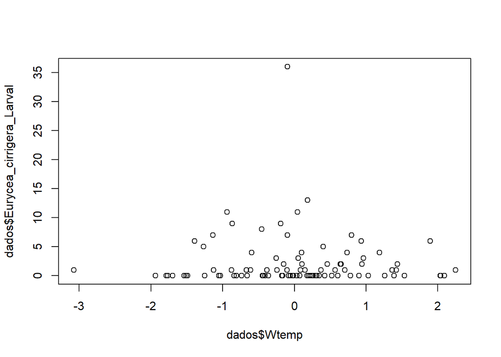

```r
#Explorando os dados
#~~~~~~~~~~~~~~~~~~~~~~~~~~~
## Distribuição dos dados (variável y)
plot(dados$Eurycea_cirrigera_Larval ~ dados$Wtemp)
```

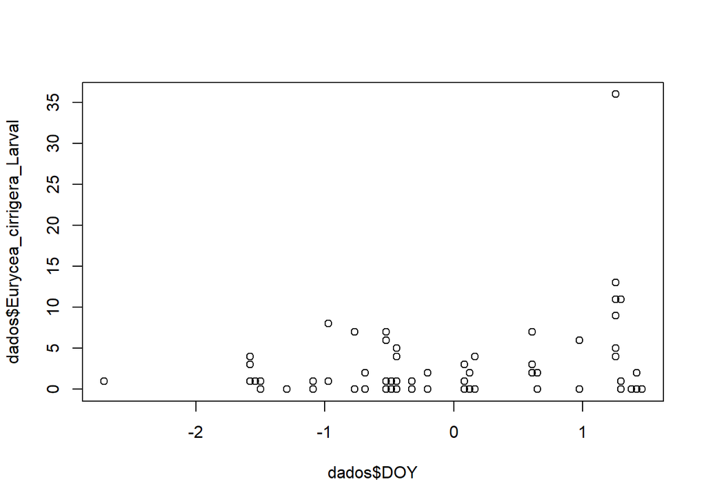

```r
plot(dados$Eurycea_cirrigera_Larval ~ dados$DOY)
```

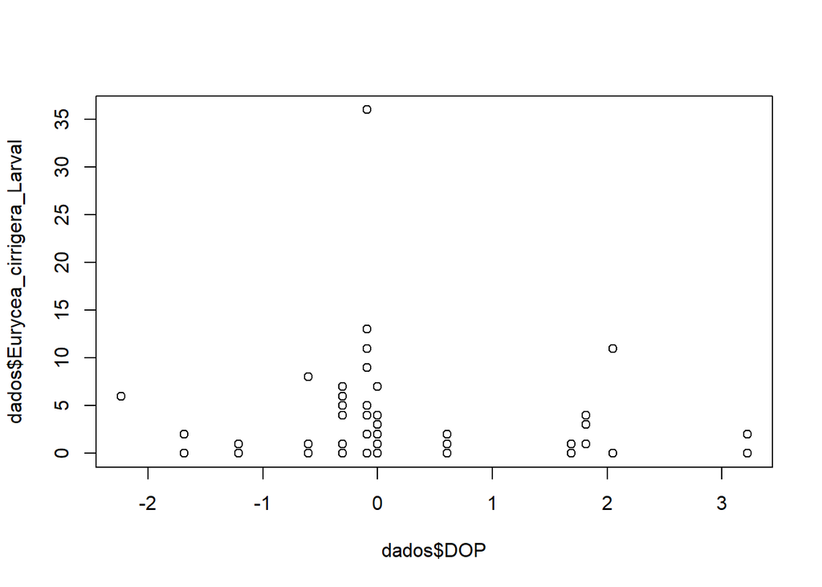

```r
plot(dados$Eurycea_cirrigera_Larval ~ dados$DOP)
```

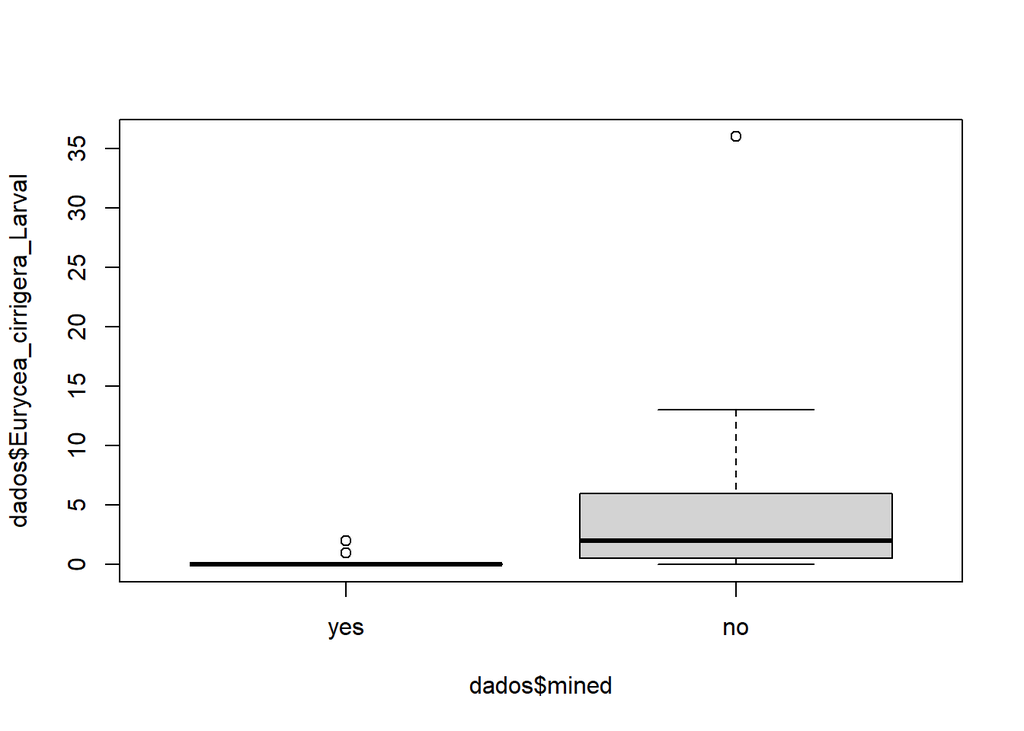

```r
plot(dados$Eurycea_cirrigera_Larval ~ dados$mined)
```

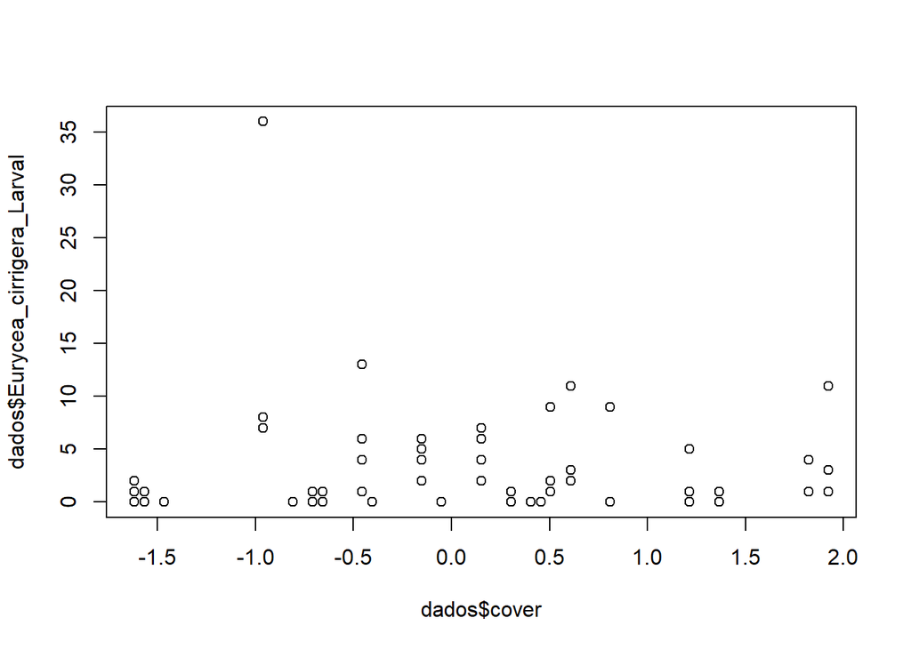

```r
plot(dados$Eurycea_cirrigera_Larval ~ dados$cover)
```

- É possível perceber que as distribuição das larvas estão em torno de temperaturas com -1 e 1 desvio padrão.

- Áreas que não sofreram com mineração possivelmente possuem maior abundância de larvas da espécie Eurycea cirrigera.

Para testar o modelo com Poisson, vou considerar as mesmas variáveis para inferir a abundância das larvas de Eurycea.

Comecei com o modelo nulo e fui adicionando complexidade com 1 variável por vez.

```r
## Modelos ##

mod_0 <-  glm( Eurycea_cirrigera_Larval ~ 1,
             data = dados,
             family = "poisson")
summary(mod_0)
```

```
##
## Call:
## glm(formula = Eurycea_cirrigera_Larval ~ 1, family = "poisson",
##     data = dados)
##
## Coefficients:
##             Estimate Std. Error z value Pr(>|z|)
## (Intercept)  0.78152    0.07053   11.08   <2e-16 ***
## ---
## Signif. codes:  0 '***' 0.001 '**' 0.01 '*' 0.05 '.' 0.1 ' ' 1
##
## (Dispersion parameter for poisson family taken to be 1)
##
##     Null deviance: 490.38  on 91  degrees of freedom
## Residual deviance: 490.38  on 91  degrees of freedom
## AIC: 624.46
##
## Number of Fisher Scoring iterations: 6
```

```r
mod_1 <- glm( Eurycea_cirrigera_Larval ~ Wtemp,
             data = dados,
             family = "poisson")

summary(mod_1)
```

```
##
## Call:
## glm(formula = Eurycea_cirrigera_Larval ~ Wtemp, family = "poisson",
##     data = dados)
##
## Coefficients:
##             Estimate Std. Error z value Pr(>|z|)
## (Intercept)  0.78092    0.07058  11.065   <2e-16 ***
## Wtemp       -0.03463    0.07078  -0.489    0.625
## ---
## Signif. codes:  0 '***' 0.001 '**' 0.01 '*' 0.05 '.' 0.1 ' ' 1
##
## (Dispersion parameter for poisson family taken to be 1)
##
##     Null deviance: 490.38  on 91  degrees of freedom
## Residual deviance: 490.14  on 90  degrees of freedom
## AIC: 626.22
##
## Number of Fisher Scoring iterations: 6
```

```r
mod_2<- glm( Eurycea_cirrigera_Larval ~ Wtemp + DOY,
              data = dados,
              family = "poisson")

summary(mod_2)
```

```
##
## Call:
## glm(formula = Eurycea_cirrigera_Larval ~ Wtemp + DOY, family = "poisson",
##     data = dados)
##
## Coefficients:
##             Estimate Std. Error z value Pr(>|z|)
## (Intercept)  0.64559    0.08026   8.044 8.69e-16 ***
## Wtemp       -0.05802    0.07253  -0.800    0.424
## DOY          0.53341    0.07749   6.884 5.83e-12 ***
## ---
## Signif. codes:  0 '***' 0.001 '**' 0.01 '*' 0.05 '.' 0.1 ' ' 1
##
## (Dispersion parameter for poisson family taken to be 1)
##
##     Null deviance: 490.38  on 91  degrees of freedom
## Residual deviance: 438.57  on 89  degrees of freedom
## AIC: 576.65
##
## Number of Fisher Scoring iterations: 6
```

```r
mod_3<- glm( Eurycea_cirrigera_Larval ~ Wtemp + DOY + mined,
             data = dados,
             family = "poisson")

summary(mod_3)
```

```
##
## Call:
## glm(formula = Eurycea_cirrigera_Larval ~ Wtemp + DOY + mined,
##     family = "poisson", data = dados)
##
## Coefficients:
##             Estimate Std. Error z value Pr(>|z|)
## (Intercept) -1.61962    0.30667  -5.281 1.28e-07 ***
## Wtemp       -0.06399    0.08718  -0.734    0.463
## DOY          0.63475    0.08315   7.634 2.27e-14 ***
## minedno      2.84641    0.31050   9.167  < 2e-16 ***
## ---
## Signif. codes:  0 '***' 0.001 '**' 0.01 '*' 0.05 '.' 0.1 ' ' 1
##
## (Dispersion parameter for poisson family taken to be 1)
##
##     Null deviance: 490.38  on 91  degrees of freedom
## Residual deviance: 247.40  on 88  degrees of freedom
## AIC: 387.48
##
## Number of Fisher Scoring iterations: 6
```

```r
mod_4<- glm( Eurycea_cirrigera_Larval ~ Wtemp + DOY + mined + DOP,
             data = dados,
             family = "poisson")

summary(mod_4)
```

```
##
## Call:
## glm(formula = Eurycea_cirrigera_Larval ~ Wtemp + DOY + mined +
##     DOP, family = "poisson", data = dados)
##
## Coefficients:
##             Estimate Std. Error z value Pr(>|z|)
## (Intercept) -1.67773    0.30797  -5.448 5.10e-08 ***
## Wtemp       -0.10020    0.08578  -1.168  0.24281
## DOY          0.65678    0.08461   7.762 8.36e-15 ***
## minedno      2.91171    0.31111   9.359  < 2e-16 ***
## DOP         -0.20172    0.06852  -2.944  0.00324 **
## ---
## Signif. codes:  0 '***' 0.001 '**' 0.01 '*' 0.05 '.' 0.1 ' ' 1
##
## (Dispersion parameter for poisson family taken to be 1)
##
##     Null deviance: 490.38  on 91  degrees of freedom
## Residual deviance: 238.25  on 87  degrees of freedom
## AIC: 380.33
##
## Number of Fisher Scoring iterations: 6
```

```r
#verificando x

mod_1$deviance/mod_1$df.residual
```

```
## [1] 5.445966
```

```r
mod_2$deviance/mod_2$df.residual
```

```
## [1] 4.927748
```

```r
mod_3$deviance/mod_3$df.residual
```

```
## [1] 2.811319
```

```r
mod_4$deviance/mod_4$df.residual
```

```
## [1] 2.738462
```

```r
#Comparando AIC

AIC(mod_0, mod_1, mod_2, mod_3, mod_4) #Comparando
```

```
##       df      AIC
## mod_0  1 624.4554
## mod_1  2 626.2164
## mod_2  3 576.6491
## mod_3  4 387.4756
## mod_4  5 380.3256
```

- O modelo 4 com todas variáveis apresentou menor AIC. Vou realizar o teste de varossimilhança entre o modelo 3 e 4 que estão muito próximos.

```r
##Teste de razão de verossimilhança ##
#lmtest::lrtest(mod3, mod2) # mesma coisa
anova(mod_3, mod_4, test = "Chisq")
```

```
## Analysis of Deviance Table
##
## Model 1: Eurycea_cirrigera_Larval ~ Wtemp + DOY + mined
## Model 2: Eurycea_cirrigera_Larval ~ Wtemp + DOY + mined + DOP
##   Resid. Df Resid. Dev Df Deviance Pr(>Chi)
## 1        88     247.40
## 2        87     238.25  1   9.1499 0.002487 **
## ---
## Signif. codes:  0 '***' 0.001 '**' 0.01 '*' 0.05 '.' 0.1 ' ' 1
```

- como p< 0,05, o modelo completo 4 é o melhor.
- Dados ecológicos apresentam a variância maior que a média, por isso, deve-se verificar a sobredispersão para avaliar se a função de probabilidade Poisson é adequada.

```r
#chacando sopredispersão
library(performance)
check_overdispersion(mod_4)
```

```
## # Overdispersion test
##
##        dispersion ratio =   3.432
##   Pearson's Chi-Squared = 298.595
##                 p-value = < 0.001
```

- A sobredispersão do modelo 4 está alta, com valor = 3,43.A superdispersão geralmente reflete heterogeneidade não modelada, por isso uma alternativa é optar pelo modelo *Binomial negativa*.

## 4 A binomial negativa (NB)

- É uma generalização da Poisson que adiciona um termo de dispersão extra, que corrige a variabilidade dos dados.

```r
## Modelos com binomial negativa
library(MASS)
mod_binegativo<- glm.nb( Eurycea_cirrigera_Larval ~ Wtemp + DOY + mined + DOP,
             data = dados)

summary(mod_binegativo)
```

```
##
## Call:
## glm.nb(formula = Eurycea_cirrigera_Larval ~ Wtemp + DOY + mined +
##     DOP, data = dados, init.theta = 0.9846584621, link = log)
##
## Coefficients:
##             Estimate Std. Error z value Pr(>|z|)
## (Intercept)  -1.5337     0.3475  -4.413 1.02e-05 ***
## Wtemp         0.1459     0.1703   0.857   0.3915
## DOY           0.3975     0.1599   2.487   0.0129 *
## minedno       2.8297     0.3882   7.289 3.12e-13 ***
## DOP          -0.1933     0.1427  -1.355   0.1755
## ---
## Signif. codes:  0 '***' 0.001 '**' 0.01 '*' 0.05 '.' 0.1 ' ' 1
##
## (Dispersion parameter for Negative Binomial(0.9847) family taken to be 1)
##
##     Null deviance: 163.120  on 91  degrees of freedom
## Residual deviance:  82.558  on 87  degrees of freedom
## AIC: 295.32
##
## Number of Fisher Scoring iterations: 1
##
##
##               Theta:  0.985
##           Std. Err.:  0.281
##
##  2 x log-likelihood:  -283.320
```

```r
## Modelos com binomial negativo
## checando sobredispersão
check_overdispersion(mod_binegativo)
```

```
## # Overdispersion test
##
##  dispersion ratio = 1.291
##           p-value = 0.448
```

- Agora com o modelo binomial negativo, a sobredispersão ficou dentro de um limite aceitável.
- Vamos analisar os resultados e os resíduos do modelo com binomial negativa.

## 5 Analisando os coeficientes estimados a partir do modelo binomial:

*DOY* (0.3975) também tem efeito positivo na contagem de larvas;

*minedno* (2.8297), mostra que locais não minerados têm mais chances de terem mais larvas do que os minerados;

## 6 Conclusão

- O modelo binomial negativa foi mais adequado devido à alta sobredispersão dos dados. De modo geral, a abundância de larvas de Eurycea cirrigera aumenta ao longo do tempo (DOY) e tende a ser muito maior em locais não impactados pela mineração.